# Logistic regression

# Preparation for logistic regression

```r
alias(delayed_or_cancelled ~ ., data = newark_factored)
```

```
Model :
delayed_or_cancelled ~ month + weekday + distance + hour + wind_dir +
    wind_speed + wind_gust + visib + carrier_name + type + engines +
    engine + tavg_c + prcp + snow

Complete :
                  (Intercept) monthAug    monthDec    monthFeb
wind_gust                   0           0           0           0
engines3                    1           0           0           0
enginesunknown              0           0           0           0
engineElectric              0           0           0           0
engineTurbo-shaft           1           0           0           0
engineunknown               0           0           0           0
                  monthJan    monthJul    monthJun    monthMar
wind_gust                   0           0           0           0
engines3                    0           0           0           0
enginesunknown              0           0           0           0
engineElectric              0           0           0           0
engineTurbo-shaft           0           0           0           0
engineunknown               0           0           0           0
                  monthMay    monthNov    monthOct    monthSep
wind_gust                   0           0           0           0
engines3                    0           0           0           0
enginesunknown              0           0           0           0
engineElectric              0           0           0           0
engineTurbo-shaft           0           0           0           0
engineunknown               0           0           0           0
                  weekdayMon  weekdaySat  weekdaySun  weekdayThu
wind_gust                   0           0           0           0
engines3                    0           0           0           0
enginesunknown              0           0           0           0
engineElectric              0           0           0           0
engineTurbo-shaft           0           0           0           0
engineunknown               0           0           0           0
                  weekdayTue  weekdayWed  distance    hour
wind_gust                   0           0           0           0
engines3                    0           0           0           0
enginesunknown              0           0           0           0
engineElectric              0           0           0           0
engineTurbo-shaft           0           0           0           0
```

[output cut: 84 more lines]

```
engineunknown               0           0           0           0
                  engineReciprocating engineTurbo-fan engineTurbo-jet
wind_gust                   0                   0               0
engines3                    0                   0               0
enginesunknown              0                   0               0
engineElectric              0                   0               0
engineTurbo-shaft          -1                  -1              -1
engineunknown               0                   0               0
                  engineTurbo-prop tavg_c      prcp        snow
wind_gust                   0                0           0           0
engines3                    0                0           0           0
enginesunknown              0                0           0           0
engineElectric              0                0           0           0
engineTurbo-shaft          -1                0           0           0
engineunknown               0                0           0           0
```

Will remove wind_gust as appears to be aliased variable.

Engines and engine both have more factors than showing in alias table. Engines has fewer variables and is simply a count of the number of engines in on each plane, have opted to remove this and keep the engine variable.

```r
newark_factored <- newark_factored %>%
  select(-c(wind_gust, engines))
```

```r
weather_factors <- newark_factored %>%
  select(delayed_or_cancelled, wind_dir, wind_speed, visib,
         tavg_c, prcp, snow)
```

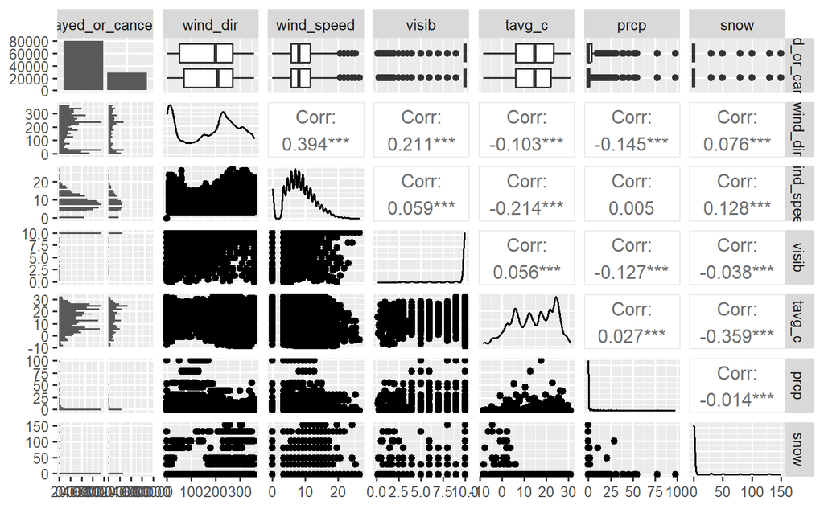

```r
weather_factors %>%
  ggpairs(progress = FALSE)
```

```r
plane_factors <- newark_factored %>%
  select(delayed_or_cancelled, type, engine)
```

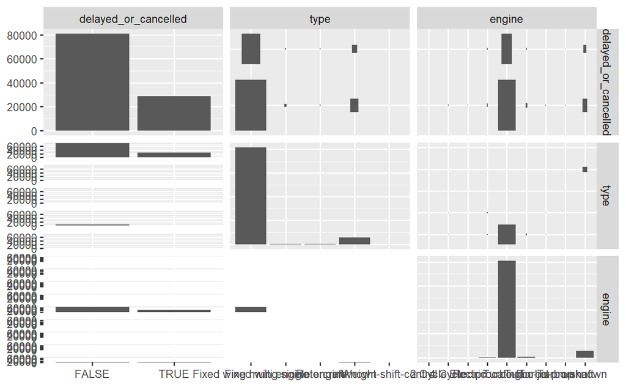

```r
plane_factors %>%
  ggpairs(progress = FALSE)
```

```r
schedule_factors <- newark_factored %>%
  select(delayed_or_cancelled, month, weekday)
```

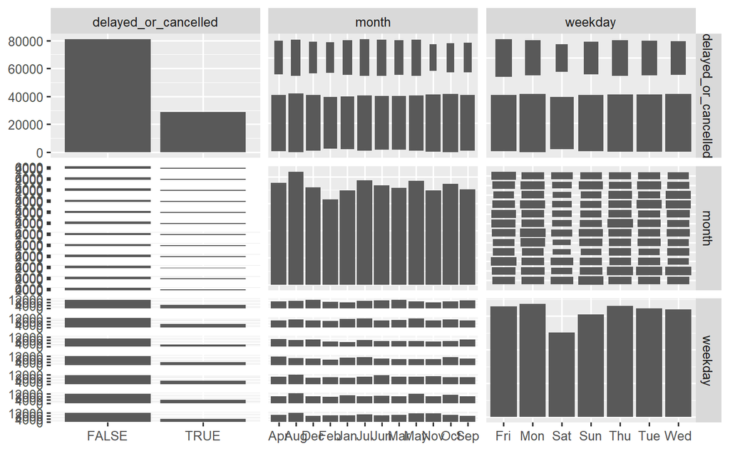

```r
schedule_factors %>%
  ggpairs(progress = FALSE)
```

GG pairs plots are difficult to interpret in this instance. Manual model building not the best option. Will use glmulti package for automated model building.

```r
newark_factored %>%
  head()
```

| month | weekday | distance | hour | wind_dir | wind_speed | visib | carrier_name | type | engine | tavg_c | prcp | snow | delayed_or_cancelled |
| --- | --- | --- | --- | --- | --- | --- | --- | --- | --- | --- | --- | --- | --- |
| Oct | Sun | 1085 | 21 | 10 | 8.05546 | 10 | United Air Lines Inc. | Fixed wing multi engine | Turbo-fan | 14.6 | 0 | 0 | TRUE |
| Oct | Sun | 631 | 9 | 10 | 12.65858 | 10 | United Air Lines Inc. | Fixed wing multi engine | Turbo-fan | 14.6 | 0 | 0 | FALSE |
| Oct | Sun | 2454 | 9 | 10 | 12.65858 | 10 | United Air Lines Inc. | Fixed wing multi engine | Turbo-fan | 14.6 | 0 | 0 | FALSE |
| Oct | Sun | 997 | 9 | 10 | 12.65858 | 10 | United Air Lines Inc. | Fixed wing multi engine | Turbo-fan | 14.6 | 0 | 0 | FALSE |
| Oct | Sun | 1605 | 9 | 10 | 12.65858 | 10 | United Air Lines Inc. | Fixed wing multi engine | Turbo-fan | 14.6 | 0 | 0 | FALSE |
| Oct | Sun | 872 | 9 | 10 | 12.65858 | 10 | Southwest Airlines Co. | Fixed wing multi engine | Turbo-fan | 14.6 | 0 | 0 | FALSE |

# Glmulti

Creating test and train data:

```r
n_rows <- nrow(newark_factored)

test_index <- sample(1:n_rows, size = n_rows*0.2)

newark_train <- slice(newark_factored, -test_index)
newark_test <- slice(newark_factored, test_index)
```

```r
newark_train %>%
  tabyl(delayed_or_cancelled)
```

```
 delayed_or_cancelled     n   percent
                FALSE 64555 0.7352506
                 TRUE 23245 0.2647494
```

```r
newark_test %>%
  tabyl(delayed_or_cancelled)
```

```
 delayed_or_cancelled     n  percent
                FALSE 16222 0.739077
                 TRUE  5727 0.260923
```

Test and train data have good distribution of outcome. Continue with glmulti model.

```r
glmulti_search_all_mains <- glmulti(
  delayed_or_cancelled ~ .,
  data = newark_train,
  level = 1,               # No interactions considered, main effects only
  method = "h",            # Exhaustive approach
  crit = "bic",            # BIC as criteria
  confsetsize = 10,        # Keep 10 best models
  plotty = F,
  report = T,              # No plots, but provide interim reports
  fitfunction = "glm",     # glm function
  family = binomial(link = "logit")) # binomial family for logistic regression
```

```
Initialization...
TASK: Exhaustive screening of candidate set.
Fitting...

After 50 models:
Best model: delayed_or_cancelled~1+distance+hour+wind_speed+visib
Crit= 91506.5363369748
Mean crit= 91740.7775057479

After 100 models:
Best model: delayed_or_cancelled~1+distance+hour+wind_dir+wind_speed+visib+prcp
Crit= 90271.5511172775
Mean crit= 90448.5336060613
```

```r
summary(glmulti_search_all_mains)
```

[output not shown]

The best model from glmulti is:

delayed_or_cancelled ~ 1 + month + weekday + carrier_name + type + hour + wind_speed + visib + tavg_c + prcp + snow”

```r
mod1 <- glm(delayed_or_cancelled ~
              month + weekday + carrier_name +
              type + hour +  wind_speed + visib + tavg_c +
              prcp + snow,
            family = binomial(link = "logit"), data = newark_train)
```

```r
roc1 <- newark_train %>%
  add_predictions(mod1, type = "response") %>%
  roc(response = delayed_or_cancelled, predictor = pred)
```

```r
auc(roc1)
```

```
Area under the curve: 0.7522
```

```r
threshold_mod1 <- 0.5

mod1_0.5 <- newark_train %>%
  add_predictions(mod1,
                  type = "response") %>%
  mutate(pred_thresh_0.5 = pred >= threshold_mod1)

conf_mod1 <- mod1_0.5 %>%
  tabyl(delayed_or_cancelled, pred_thresh_0.5)

conf_mod1
```

```
 delayed_or_cancelled FALSE TRUE
                FALSE 60953 3602
                 TRUE 17020 6225
```

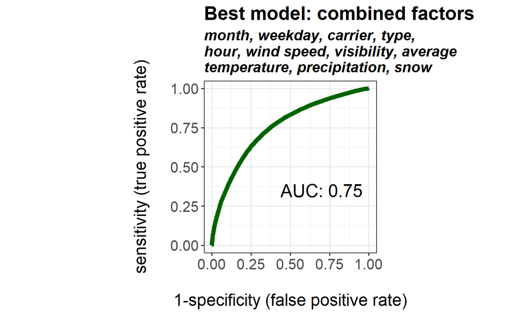

```r
label_best_auc <- str_c(
  "AUC: ", round(auc(roc1),2))

(roc_curve1 <- ggroc(data = roc1,
                     legacy.axes = TRUE,
                     color = "darkgreen",
                     size = 2) +
   coord_fixed() +
    labs(title = "Best model: combined factors",
         subtitle = "month, weekday, carrier, type,
hour, wind speed, visibility, average
temperature, precipitation, snow",
x = "\n1-specificity (false positive rate)",
y = "sensitivity (true positive rate)\n"
    ) +
   annotate("text", x = 0.70, y = 0.35,
            label = label_best_auc,
            size= 6) +
   theme_bw()) +
  theme(plot.title = element_text(
    face = "bold", size = 18),
    plot.subtitle = element_text(
      face = "bold.italic", size = 14),
    text = element_text(size = 16),
    axis.text.x = element_text(size = 14),
    axis.text.y = element_text(size = 14))

ggsave("images/proc_best_model.png",
       height = 7, width = 7)
```

Performing glmulti including interaction to test if model is better:

```r
glmulti_search_all_mains_one_pair <- glmulti(
  delayed_or_cancelled ~ month + weekday + carrier_name +
              type + hour +  wind_speed + visib + tavg_c +
              prcp + snow,
  data = newark_train,
  level = 2,               # Interactions considered
  method = "h",            # Exhaustive approach
  crit = "bic",            # BIC as criteria
  confsetsize = 10,        # Keep 10 best models
  marginality = TRUE,      # consider pairs only if both main effects in model
  minsize = 11,             # minsize, maxsize and marginality here force
  maxsize = 11,             # inclusion of a single pair beyond the ten main effects
  plotty = F,
  report = T,              # No plots, but provide interim reports
  fitfunction = "glm",     # glm function
  family = binomial(link = "logit")) # binomial family for logistic regression
```

```
Initialization...
TASK: Exhaustive screening of candidate set.
Fitting...
```

Interrupted after 12 hours of running:

After 63800 models: Best model: delayed_or_cancelled~1+month+hour+wind_speed+visib+tavg_c+prcp+snow+tavg_c:hour+snow:prcp+month:tavg_c+month:prcp Crit= 87583.5569166449 Mean crit= 87625.7595997976

```r
mod2 <- glm(delayed_or_cancelled ~ month + hour + wind_speed + visib + tavg_c + prcp + snow + tavg_c:hour + snow:prcp + month:tavg_c + month:prcp,
            family = binomial(link = "logit"), data = newark_train)
```

```r
roc2 <- newark_train %>%
  add_predictions(mod2, type = "response") %>%
  roc(response = delayed_or_cancelled, predictor = pred)
```

```r
auc(roc2)
```

```
Area under the curve: 0.7495
```

AUC is smaller than model without interactions. Interaction model not competitive.

```r
roc1_test <- newark_test %>%
  add_predictions(mod1, type = "response") %>%
  roc(response = delayed_or_cancelled, predictor = pred)
```

```r
auc(roc1_test)
```

```
Area under the curve: 0.7545
```

Model seems to fit data well.

## Logistic regression with weather variables only - backward selection

With all weather related variables:

```r
mod1_weather <- glm(delayed_or_cancelled ~
                    wind_dir + wind_speed +
                    visib + tavg_c + prcp + snow,
                    data = newark_train,
                    family = binomial(link = "logit"))

summary(mod1_weather)
```

```
Call:
glm(formula = delayed_or_cancelled ~ wind_dir + wind_speed +
    visib + tavg_c + prcp + snow, family = binomial(link = "logit"),
    data = newark_train)

Deviance Residuals:
    Min       1Q   Median       3Q      Max
-1.8783  -0.7542  -0.7166   1.2096   1.8435

Coefficients:
              Estimate Std. Error z value Pr(>|z|)
(Intercept) -4.893e-01  4.108e-02 -11.911  < 2e-16 ***
wind_dir    -6.287e-05  7.640e-05  -0.823    0.411
wind_speed   8.126e-03  1.940e-03   4.189  2.8e-05 ***
visib       -9.470e-02  3.949e-03 -23.978  < 2e-16 ***
tavg_c       1.090e-02  9.321e-04  11.699  < 2e-16 ***
prcp         2.316e-02  7.376e-04  31.400  < 2e-16 ***
snow         9.751e-03  3.854e-04  25.302  < 2e-16 ***
---
Signif. codes:  0 ‘***’ 0.001 ‘**’ 0.01 ‘*’ 0.05 ‘.’ 0.1 ‘ ’ 1

(Dispersion parameter for binomial family taken to be 1)

    Null deviance: 101491  on 87799  degrees of freedom
Residual deviance:  98976  on 87793  degrees of freedom
AIC: 98990

Number of Fisher Scoring iterations: 4
```

```r
bic(mod1_weather)
```

```
[1] 99056.17
```

wind_dir is not significant - remove. BIC is much higher than that of glmulti model with additional (non-weather) factors.

```r
mod2_weather <- glm(delayed_or_cancelled ~ wind_speed +
                    visib + tavg_c + prcp + snow,
                    data = newark_train,
                    family = binomial(link = "logit"))

summary(mod2_weather)
```

```
Call:
glm(formula = delayed_or_cancelled ~ wind_speed + visib + tavg_c +
    prcp + snow, family = binomial(link = "logit"), data = newark_train)

Deviance Residuals:
    Min       1Q   Median       3Q      Max
-1.8815  -0.7544  -0.7165   1.2100   1.8467

Coefficients:
              Estimate Std. Error z value Pr(>|z|)
(Intercept) -0.4897895  0.0410778 -11.923  < 2e-16 ***
wind_speed   0.0075398  0.0018051   4.177 2.96e-05 ***
visib       -0.0953619  0.0038665 -24.664  < 2e-16 ***
tavg_c       0.0109125  0.0009318  11.712  < 2e-16 ***
prcp         0.0232504  0.0007300  31.850  < 2e-16 ***
snow         0.0097405  0.0003852  25.288  < 2e-16 ***
---
Signif. codes:  0 ‘***’ 0.001 ‘**’ 0.01 ‘*’ 0.05 ‘.’ 0.1 ‘ ’ 1

(Dispersion parameter for binomial family taken to be 1)

    Null deviance: 101491  on 87799  degrees of freedom
Residual deviance:  98977  on 87794  degrees of freedom
AIC: 98989

Number of Fisher Scoring iterations: 4
```

```r
bic(mod2_weather)
```

```
[1] 99045.46
```

BIC still much higher that glmulti model.

Further testing of weather only model (mod2_weather):

```r
roc_weather <- newark_train %>%
  add_predictions(mod2_weather, type = "response") %>%
  roc(response = delayed_or_cancelled, predictor = pred)
```

```r
auc(roc_weather)
```

```
Area under the curve: 0.6003
```

```r
roc_weather_test <- newark_test %>%
  add_predictions(mod2_weather, type = "response") %>%
  roc(response = delayed_or_cancelled, predictor = pred)
```

```r
auc(roc_weather_test)
```

```
Area under the curve: 0.5988
```

Model fits data well.

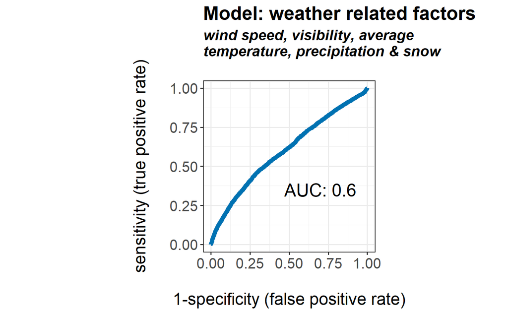

```r
#plotting roc curve for best weather model

label_weather_auc <- str_c(
  "AUC: ", round(auc(roc_weather_test),2))

(roc_curve_weather <- ggroc(data = roc_weather,
                            legacy.axes = TRUE,
                            colour = "#0072B2",
                            size = 2) +
    coord_fixed() +
    labs(title = "Model: weather related factors",
         subtitle = "wind speed, visibility, average
temperature, precipitation & snow\n",
x = "\n1-specificity (false positive rate)",
y = "sensitivity (true positive rate)\n"
    ) +
    annotate("text", x = 0.70, y = 0.35,
             label = label_weather_auc,
             size= 6) +
    theme_bw()) +
  theme(plot.title = element_text(
    face = "bold", size = 18),
    plot.subtitle = element_text(
      face = "bold.italic", size = 14),
    text = element_text(size = 16),
    axis.text.x = element_text(size = 14),
    axis.text.y = element_text(size = 14))
```

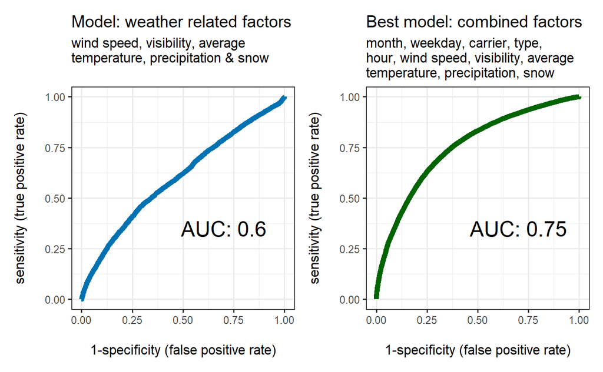

```r
roc_curve_weather + roc_curve1

ggsave("roc_curves.png", width = 10, height = 6)
```

## Weather factors and cancelled flights

```r
newark_factored_cancelled <- newark_info %>%
  select(-c(year, day, origin, dep_delay, carrier,
            dep_time, dest, sched_dep_time, tailnum,
            time_hour, date, flight, manufacturer,
            model)) %>%
  mutate(across(c(month, weekday,
         carrier_name,
         type,
         engines,
         engine),
                ~as.factor(.x))) %>%
  # combining cancelled and delayed to "delayed" for binary outcome
  mutate(cancelled = as.logical(
    if_else(status == "cancelled", TRUE, FALSE))) %>%
  select(-status)
```

Creating new test and training data:

```r
n_rows_cancelled <- nrow(newark_factored_cancelled)

test_index_cancelled <- sample(1:n_rows, size = n_rows*0.2)

newark_train_cancelled <- slice(
  newark_factored_cancelled, -test_index)
newark_test_cancelled <- slice(
  newark_factored_cancelled, test_index)
```

```r
newark_train_cancelled %>%
  tabyl(cancelled)
```

```
 cancelled     n    percent
     FALSE 85726 0.97637813
      TRUE  2074 0.02362187
```

```r
newark_test_cancelled %>%
  tabyl(cancelled)
```

```
 cancelled     n    percent
     FALSE 21416 0.97571643
      TRUE   533 0.02428357
```

Equal distribution in test and train data.

```r
mod1_weather_cancelled <- glm(cancelled ~
                    wind_dir + wind_speed +
                    visib + tavg_c + prcp + snow,
                    data = newark_train_cancelled,
                    family = binomial(link = "logit"))

summary(mod1_weather_cancelled)
```

```
Call:
glm(formula = cancelled ~ wind_dir + wind_speed + visib + tavg_c +
    prcp + snow, family = binomial(link = "logit"), data = newark_train_cancelled)

Deviance Residuals:
    Min       1Q   Median       3Q      Max
-1.2155  -0.2057  -0.1804  -0.1559   3.1988

Coefficients:
              Estimate Std. Error z value Pr(>|z|)
(Intercept) -3.9877387  0.1087110 -36.682  < 2e-16 ***
wind_dir    -0.0010105  0.0002301  -4.391 1.13e-05 ***
wind_speed   0.0400020  0.0055792   7.170 7.51e-13 ***
visib       -0.0889174  0.0094775  -9.382  < 2e-16 ***
tavg_c       0.0322255  0.0030577  10.539  < 2e-16 ***
prcp         0.0374311  0.0010350  36.164  < 2e-16 ***
snow         0.0211142  0.0007733  27.306  < 2e-16 ***
---
Signif. codes:
0 ‘***’ 0.001 ‘**’ 0.01 ‘*’ 0.05 ‘.’ 0.1 ‘ ’ 1

(Dispersion parameter for binomial family taken to be 1)

    Null deviance: 19635  on 87799  degrees of freedom
Residual deviance: 17810  on 87793  degrees of freedom
AIC: 17824

Number of Fisher Scoring iterations: 7
```

All weather factors have significant p-values.

```r
bic(mod1_weather_cancelled)
```

```
[1] 17889.43
```

```r
roc_weather_cancelled <- newark_train_cancelled %>%
  add_predictions(mod1_weather_cancelled,
                  type = "response") %>%
  roc(response = cancelled, predictor = pred)
```

```r
auc(roc_weather_cancelled)
```

```
Area under the curve: 0.7436
```

Confusion matrix for cancelled model

```r
threshold <- 0.5

weather_cancelled_0.5 <- newark_train_cancelled %>%
  add_predictions(mod1_weather_cancelled,
                  type = "response") %>%
  mutate(pred_thresh_0.5 = pred >= threshold)

conf_weather_cancelled <- weather_cancelled_0.5 %>%
  tabyl(cancelled, pred_thresh_0.5)

conf_weather_cancelled
```

```
 cancelled FALSE TRUE
     FALSE 85712   14
      TRUE  2071    3
```

# Removing on time and setting binary classifier to cancelled or delayed

```r
newark_cancelled <- newark_info %>%
  filter(status != "on time") %>%
  select(-c(year, day, origin, dep_delay, carrier,
            dep_time, dest, sched_dep_time, tailnum,
            time_hour, date, flight, manufacturer,
            model)) %>%
  mutate(across(c(month, weekday,
         carrier_name,
         type,
         engines,
         engine),
                ~as.factor(.x))) %>%
  # adding variable for cancelled, if false then delayed only
  mutate(cancelled = as.logical(
    if_else(status == "cancelled", TRUE, FALSE))) %>%
  select(-status)
```

Creating new test and training data:

```r
n_rows_cancelled2 <- nrow(newark_cancelled)

test_index_cancelled2 <- sample(1:n_rows, size = n_rows*0.2)

train_cancelled2 <- slice(
  newark_cancelled, -test_index)

test_cancelled2 <- slice(
  newark_cancelled, test_index)
```

```r
train_cancelled2 %>%
  tabyl(cancelled)
```

```
 cancelled     n    percent
     FALSE 21079 0.90877344
      TRUE  2116 0.09122656
```

```r
test_cancelled2 %>%
  tabyl(cancelled)
```

```
 cancelled    n    percent
     FALSE 5286 0.91500779
      TRUE  491 0.08499221
```

Equal distribution in test and train data.

```r
mod1_cancelled <- glm(cancelled ~
                    wind_dir + wind_speed +
                    visib + tavg_c + prcp + snow,
                    data = newark_cancelled,
                    family = binomial(link = "logit"))

summary(mod1_cancelled)
```

```
Call:
glm(formula = cancelled ~ wind_dir + wind_speed + visib + tavg_c +
    prcp + snow, family = binomial(link = "logit"), data = newark_cancelled)

Deviance Residuals:
    Min       1Q   Median       3Q      Max
-1.4714  -0.4116  -0.3694  -0.3228   2.6375

Coefficients:
              Estimate Std. Error z value Pr(>|z|)
(Intercept) -3.0720814  0.1008584 -30.459  < 2e-16 ***
wind_dir    -0.0006647  0.0002136  -3.112  0.00186 **
wind_speed   0.0290187  0.0050252   5.775 7.71e-09 ***
visib       -0.0219671  0.0089989  -2.441  0.01464 *
tavg_c       0.0266315  0.0027364   9.732  < 2e-16 ***
prcp         0.0322980  0.0011619  27.797  < 2e-16 ***
snow         0.0161066  0.0007358  21.891  < 2e-16 ***
---
Signif. codes:
0 ‘***’ 0.001 ‘**’ 0.01 ‘*’ 0.05 ‘.’ 0.1 ‘ ’ 1

(Dispersion parameter for binomial family taken to be 1)

    Null deviance: 17528  on 28971  degrees of freedom
Residual deviance: 16234  on 28965  degrees of freedom
AIC: 16248

Number of Fisher Scoring iterations: 5
```

All weather factors have significant p-values.

```r
bic(mod1_cancelled)
```

```
[1] 16305.82
```

```r
roc_cancelled <- newark_cancelled %>%
  add_predictions(mod1_cancelled,
                  type = "response") %>%
  roc(response = cancelled, predictor = pred)
```

```r
auc(roc_cancelled)
```

```
Area under the curve: 0.7014
```

Confusion matrix for cancelled only model

```r
threshold2 <- 0.5

cancelled_0.5 <- newark_cancelled %>%
  add_predictions(mod1_cancelled,
                  type = "response") %>%
  mutate(pred_thresh_0.5 = pred >= threshold)

conf_cancelled <- cancelled_0.5 %>%
  tabyl(cancelled, pred_thresh_0.5)

conf_cancelled
```

```
 cancelled FALSE TRUE
     FALSE 26267   98
      TRUE  2561   46
```